# StatR 101: Lab 11

## December 3, 2012

## 1: One-way Analysis of Variance: the Pie Example

### a) First, by hand

For this lab, we will refer to the ZOD experiment in the lecture.

```r
ZOD <- c(0, 0.5, 1.5, 2, 1, 2, 2, 3, 5, 5.5, 6.5, 7)
Pie <- c(rep("A", 4), rep("B", 4), rep("C", 4))
```

Let's make `Pie` a factor:

```r
Pie <- factor(Pie)
levels(Pie)
```

```
## [1] "A" "B" "C"
```

And - as always in factorial-type data, draw a boxplot

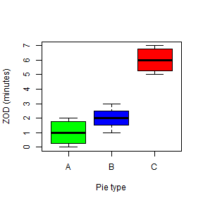

```r
boxplot(ZOD ~ Pie, col = c("green", "blue", "red"), ylab = "ZOD (minutes)",
    xlab = "Pie type")
```

Also, as with all analyses, it is helpful to generate a table of summary statistics:

```r
SummaryTable <- data.frame(n = tapply(ZOD, Pie, length), mean = tapply(ZOD,
    Pie, mean), sd = tapply(ZOD, Pie, sd))
SummaryTable
```

```
##   n mean     sd
## A 4    1 0.9129
## B 4    2 0.8165
## C 4    6 0.9129
```

As a general rule, it is helpful to record summary tables like these in separate files. For example:

```r
write.csv(SummaryTable, file = "SummaryTable.csv")
```

Ok, let's start collecting all the little pieces of ANOVA:

```r
X <- Pie
Y <- ZOD
a <- 3
n <- 4
N <- 3 * 4
```

Recall the definition of the *total sums of squares* and the *treatment (or group [or model]) sum of squares*: \[ SS_{total} = \sum_{j=1}^a \sum_{i=1}^n (Y_{ij} - \overline{Y_{\cdot\cdot}})^2 \] \[ SS_{treatment} = \sum_{j=1}^a \sum_{i=1}^n (Y_{j\cdot} - \overline{Y_{\cdot\cdot}})^2 = n \sum_{j=1}^a (Y_{j\cdot} - \overline{Y_{\cdot\cdot}})^2 \]

```r
Y.means <- tapply(Y, X, mean)
SS.total <- sum((Y - mean(Y))^2)
SS.treatment <- n * sum((Y.means - mean(Y))^2)
```

The `SS.error` can be obtained in one of two ways. Either by the definition, which is \[ SS_{error} = \sum_{j=1}^a \sum_{i=1}^n (Y_{ij} - \overline{Y}_{i\cdot})^2, \] or simply as the difference of the `SS.total` and the `SS.treatment`.

```r
SS.error <- SS.total - SS.treatment
```

> **EXERCISE:** Calculate the error sum of squares in R using the mathematical definition above and confirm that if gives the same result.

Next, we compute the *mean square of the errors* and the *mean square of the treatment (or group)*.

```r
MS.error <- SS.error/(N - a)
MS.treatment <- SS.treatment/(a - 1)
```

And obtain the *F*-statistic:

```r
F0 <- MS.treatment/MS.error
```

And compute the *p*-value:

```r
1 - pf(F0, 2, 9)
```

```
## [1] 5.081e-05
```

Clearly, we can reject the null hypothesis that there is no relationship between Pie type and Zone-Out Duration.

### b) Using R

Of course, all of this could be performed in R. But it takes two steps. The first (and this should be somewhat familiar looking) is to *specify the linear model*

```r
Pie.lm <- lm(ZOD ~ Pie)
```

Recall that the notation `Y ~ X` means that we are modeling `Y` as a response to explanatory factor `X`, i.e. \( Y_{ij} = \mu_i + \epsilon_{ij} \). The `lm` part tells us that the \( \epsilon \)'s are indpendent and identically distributed (iid) and normal, i.e. \( \epsilon_{ij} \sim {\cal N}(0,\sigma^2) \).

Look at the output of `summary(Pie.lm)`

```r
summary(Pie.lm)
```

```
##
## Call:
## lm(formula = ZOD ~ Pie)
##
## Residuals:
##    Min     1Q Median     3Q    Max
## -1.000 -0.625  0.000  0.625  1.000
##
## Coefficients:
##             Estimate Std. Error t value Pr(>|t|)
## (Intercept)    1.000      0.441    2.27     0.05 *
## PieB           1.000      0.624    1.60     0.14
## PieC           5.000      0.624    8.02  2.2e-05 ***
## ---
## Signif. codes:  0 '***' 0.001 '**' 0.01 '*' 0.05 '.' 0.1 ' ' 1
##
## Residual standard error: 0.882 on 9 degrees of freedom
## Multiple R-squared: 0.889,   Adjusted R-squared: 0.864
## F-statistic:   36 on 2 and 9 DF,  p-value: 5.08e-05
```

Note that this gives somewhat confusing output (what is `Intercept`? Why is `PieB` “1”, when its mean is 2.0? What are the `t-tests` it is performing?). The short interpretation of this output is that it is not very useful.

However, the `Pie.lm` is a “fitted model object”“, which contains a lot of useful information. Note all the named components of this object:

```r
names(Pie.lm)
```

```
##  [1] "coefficients"  "residuals"     "effects"       "rank"
##  [5] "fitted.values" "assign"        "qr"            "df.residual"
##  [9] "contrasts"     "xlevels"       "call"          "terms"
## [13] "model"
```

Important features of the model are the *model predictions*:

```r
Pie.lm$fit
```

```
##  1  2  3  4  5  6  7  8  9 10 11 12
##  1  1  1  1  2  2  2  2  6  6  6  6
```

and the *model residuals*:

```r
Pie.lm$res
```

```
##          1          2          3          4          5          6
## -1.000e+00 -5.000e-01  5.000e-01  1.000e+00 -1.000e+00 -8.327e-17
##          7          8          9         10         11         12
## -8.327e-17  1.000e+00 -1.000e+00 -5.000e-01  5.000e-01  1.000e+00
```

Note, immediately, that this object make finding the residual sum of squares instant:

```r
sum(Pie.lm$res^2)
```

```
## [1] 7
```

Before we perform the analysis of variance, it is import to verify the assumptions of ANOVA, which are related to the residuals. The simplest, most efficient, and often sufficient way to verify these is by plotting the linear model directly:

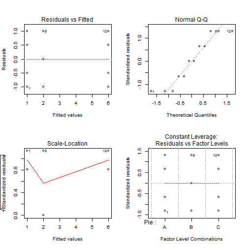

```r
par(mfrow = c(2, 2))
plot(Pie.lm)
```

The imporant plots here are the first two. They indicate that the residuals have consistent variances and are roughly normal, suggesting that the assumptions are valid.

> **EXERCISE**: Use the `Pie.lm` object to create the first plots by hand.

Ok, now that we have confirmed that the assumptions of ANOVA are supported, we can shoot the magic bullet:

```r
anova(Pie.lm)
```

```
## Analysis of Variance Table
##
## Response: ZOD
##           Df Sum Sq Mean Sq F value  Pr(>F)
## Pie        2     56   28.00      36 5.1e-05 ***
## Residuals  9      7    0.78
## ---
## Signif. codes:  0 '***' 0.001 '**' 0.01 '*' 0.05 '.' 0.1 ' ' 1
```

There it is: instant ANOVA. Double check that the results of the ANOVA conforms with our results. Note, as always, that the output of `anova` is a named list:

```r
names(anova(Pie.lm))
```

```
## [1] "Df"      "Sum Sq"  "Mean Sq" "F value" "Pr(>F)"
```

out of which any component can be easily extracted, for example:

```r
anova(Pie.lm)$Sum
```

```
## [1] 56  7
```

> **Exercise**: perform an analysis of variance on a random resampling of the ZOD (or Pie) data. Do you expect there to be a significant effect of Pie?

## 2. Two-Way ANOVA: Analysis of Cow Growth

A so-called 2-way ANOVA is essentially similar to a 1-way ANOVA, but explores 2 main effects AND a potential interaction effect.

We will look at some data on growth of a cow under three different diets (barley, oats and wheat) and three diet supplements, plus a control group with no supplements. The response variable is weekly weight gain on individual cows. The data are posted here:

```r
Growth <- read.csv("http://faculty.washington.edu/eliezg/data/Growth.csv")
```

I discovered a fun package called `googleVis`, which allows you to generate a Google style html table (as well as lots of other Google style visualizations with R/Markdown/knitr, see examples here: http://www.r-bloggers.com/googlevis-0-3-2-is-released-better-integration-with-knitr/).

```r
require(googleVis)
print(gvisTable(Growth, options = list(height = 300)), "chart")
```

[output not shown]

(<sub>Note: I took these data from *The R Book* by Michael Crawley, Wiley 2007: http://www.bio.ic.ac.uk/research/mjcraw/therbook/.</sub>)

Note that the supplement factor levels are ordered alphabetically

```r
levels(Growth$supplement)
```

```
## [1] "agrimore"  "control"   "supergain" "supersupp"
```

Which awkwardly places "control” second. A reordering of factors might be in order (so to speak). There is a convenient function called `relevel` which does exactly that:

```r
Growth$supplement <- relevel(Growth$supplement, ref = "control")
```

[figure not shown]

```r
par(cex.lab = 1.25, cex.axis = 1.1, mar = c(4, 4, 2, 2), bty = "l")
layout(rbind(c(1, 2), c(3, 3)))
boxplot(gain ~ diet, data = Growth, col = 2:4, ylab = "Weight gain (kg)", main = "Diet",
    srt = 45)
boxplot(gain ~ supplement, data = Growth, col = "grey", ylab = "Weight gain (kg)",
    main = "Supplement")
boxplot(gain ~ diet * supplement, at = c(-0.5, 0, 0.5) + rep(1:4 * 3, each = 3),
    data = Growth, col = 2:4, xaxt = "n", ylab = "Weight gain (kg)", main = "Diet x Supplement")
axis(1, at = 1:4 * 3, labels = levels(supplement))
legend("topleft", legend = levels(diet), fill = 2:4, bty = "n")
```

These boxplots are quite illuminating, showing likely significant main effects. The open question is: are there significant “interaction effects”? I.e., do different supplements in combination with different grains act in different ways on weight growth?

One quick way to visualize this question is to look at “interaction plots”:

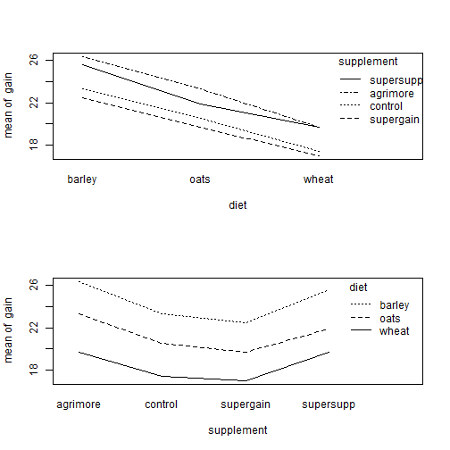

```r
par(mfrow = c(2, 1))
interaction.plot(diet, supplement, gain)
interaction.plot(supplement, diet, gain)
```

The fact that these lines are fairly parallel, suggests that the effects of the supplements are similar across all diets.

As usual, it is often very useful to generate a summary table of the data. We'll use `tapply`, but in a somewhat different way this time, structuring the application with a list.

```r
tapply(gain, list(diet, supplement), mean)
```

```
##        agrimore control supergain supersupp
## barley    26.35   23.30     22.47     25.58
## oats      23.30   20.49     19.66     21.86
## wheat     19.64   17.41     17.01     19.67
```

With some manipulation, we can make a decent looking table of means and standard deviations:

```r
M <- tapply(gain, list(supplement, diet), mean)
S <- tapply(gain, list(supplement, diet), sd)
Summary <- M
Summary[1:length(Summary)] <- paste(round(M, 1), " (", round(S, 2), ")", sep = "")
Summary <- data.frame(Supplement = levels(supplement), Summary)
print(gvisTable(Summary, options = list(height = 150)), "chart")
```

[output not shown]

Ok, with little further ado, let's perform an analysis of variance in three short steps. First, fit the linear model:

```r
Growth.lm <- lm(gain ~ diet * supplement, data = Growth)
```

Second, look at the diagnostic plots:

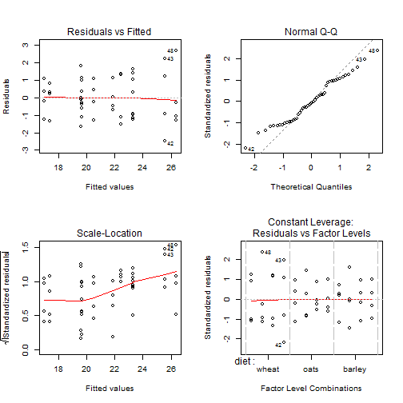

```r
par(mfrow = c(2, 2))
plot(Growth.lm)
```

The diagnostic plots look fine. Finally, compute the anova table:

```r
anova(Growth.lm)
```

```
## Analysis of Variance Table
##
## Response: gain
##                 Df Sum Sq Mean Sq F value Pr(>F)
## diet             2  287.2   143.6   83.52  3e-14 ***
## supplement       3   91.9    30.6   17.81  3e-07 ***
## diet:supplement  6    3.4     0.6    0.33   0.92
## Residuals       36   61.9     1.7
## ---
## Signif. codes:  0 '***' 0.001 '**' 0.01 '*' 0.05 '.' 0.1 ' ' 1
```

The p-values here suggest strongly that there are highly significant main effects, but no significant interaction effects. The supplements act in similar ways across all basic feed types, and there is strong evidence that Argimore and Supersupp are the superior supplement, whereas supergain might be made out of sawdust.

> **Topic for discussion**: Each p-value represents a hypothesis test.  
> What exactly are the hypotheses being tested?

## 3. Inference on Linear Regression

Load the sleep data:

```r
Sleep.df <- read.csv("http://faculty.washington.edu/eliezg/data/Sleep.csv")
Sleep <- Sleep.df$Sleep
ZOD <- Sleep.df$ZOD
```

Or, by hand:

```r
Sleep <- c(2.6, 4.2, 4.3, 4.8, 4.9, 5.3, 5.5, 5.6, 5.6, 6.5, 6.8, 7.8, 7.8,
    8, 8.4)
ZOD <- c(13, 8, 13, 10, 10, 9, 8, 10, 9, 1, 4, 3, 2, 0, 6)
```

Plot the data:

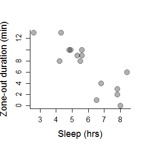

```r
plot(Sleep, ZOD, xlab = "Sleep (hrs)", ylab = "Zone-out duration (min)", pch = 19,
    col = rgb(0, 0, 0, 0.3), cex = 2)
```

We've already estimated regression parameters in this class, but as a brief review, here is how you obtain \( \widehat\alpha \) and \( \widehat\beta \):

```r
Sleep.mean <- mean(Sleep)
ZOD.mean <- mean(ZOD)
(beta.hat <- sum((Sleep - Sleep.mean) * (ZOD - ZOD.mean))/sum((Sleep - Sleep.mean)^2))
```

```
## [1] -2.117
```

```r
(alpha.hat <- ZOD.mean - alpha.hat * Sleep.mean)
```

[output not shown]

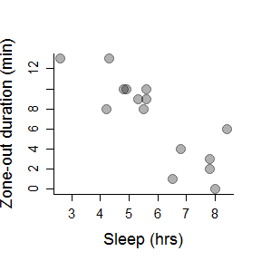

```r
plot(Sleep, ZOD, xlab = "Sleep (hrs)", ylab = "Zone-out duration (min)", pch = 19,
    col = rgb(0, 0, 0, 0.3), cex = 2)
```

```r
abline(beta.hat, alpha.hat, col = 2, lwd = 2)
```

[output not shown]

Now, lets let `R` fit the linear model

```r
Sleep.lm <- lm(ZOD ~ Sleep)
summary(Sleep.lm)
```

```
##
## Call:
## lm(formula = ZOD ~ Sleep)
##
## Residuals:
##    Min     1Q Median     3Q    Max
## -4.740 -1.051  0.143  1.113  4.283
##
## Coefficients:
##             Estimate Std. Error t value Pr(>|t|)
## (Intercept)   19.503      2.335    8.35  1.4e-06 ***
## Sleep         -2.117      0.384   -5.52  9.9e-05 ***
## ---
## Signif. codes:  0 '***' 0.001 '**' 0.01 '*' 0.05 '.' 0.1 ' ' 1
##
## Residual standard error: 2.37 on 13 degrees of freedom
## Multiple R-squared: 0.701,   Adjusted R-squared: 0.678
## F-statistic: 30.5 on 1 and 13 DF,  p-value: 9.89e-05
```

Note that the output of the linear model summary has some t-values attached to the two coeffients. In contrast to the fitted factor model above, these t-values correspond to useful tests. Specifically, they test: \( H_0: \alpha = 0 \) and \( H_0: \beta = 0 \). It turns out that the statistic: \[ t_\beta = \frac{\widehat{\beta}}{MSE}\sum_{i=1}^n {X_i - \overline{X})^2} \] happens to have a \( {\cal T(\nu = n-2)} \) distribution under the null-hypothesis. And a similar statistic can be constructed for the intercept \( \widehat{\alpha} \).

Of course, it is somewhat more straightforward to compute the ANOVA table:

```r
anova(Sleep.lm)
```

```
## Analysis of Variance Table
##
## Response: ZOD
##           Df Sum Sq Mean Sq F value  Pr(>F)
## Sleep      1  171.7   171.7    30.5 9.9e-05 ***
## Residuals 13   73.3     5.6
## ---
## Signif. codes:  0 '***' 0.001 '**' 0.01 '*' 0.05 '.' 0.1 ' ' 1
```

Note that the *p*-value is very small (highly significant), and exactly equal to the \( p \)-value on the slope in the `summary()` command. This is not a coincidence, the *F*-statistic used in the ANOVA is exactly the square of the \( t \)-statistic above.

> **Quick exercise:** Confirm this fact by extracting the *t*-statistic from the summary output. (Hint: it is hidden under the `$coef` portion of the summary object).

We know that the *T* distribution models the ratio between a \( {\cal N}(0,1) \) and the square root of a \( \chi^2 \) random variable, so it is perhaps unsurprising that the square of that statistic has the appropriate *F* null-distribution. Before we forget, we should always plot the diagnostic plots.

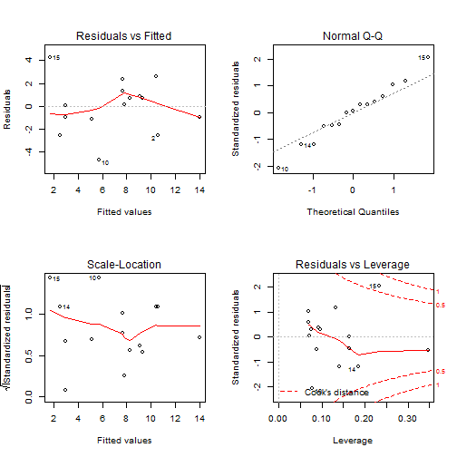

```r
plot(Sleep.lm)
```

> **Exercise:** Randomize either Sleep or ZOD and perform this regression (i.e. plot the relatinship, fit the linear model, draw the regression line, and perform an ANOVA). Do this a bunch of times. Do you ever geta significant result at the 5% significance level?

## 4. ANCOVA: Continuous and Discrete covariates

```r
PieSleep.df <- read.csv("http://faculty.washington.edu/eliezg/data/PieSleep.csv")
print(gvisTable(PieSleep.df, options = list(height = 200, width = 200)), "chart")
```

```r
Pie <- PieSleep.df$Pie
Sleep <- PieSleep.df$Sleep
ZOD <- PieSleep.df$ZOD
```

Note that a quick one-way ANOVA against the Pie effect=is not significant:

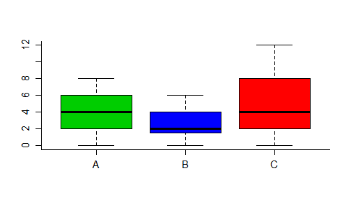

```r
boxplot(ZOD ~ Pie, col = c(3, 4, 2))
```

```r
tapply(ZOD, Pie, mean)
```

```
##     A     B     C
## 3.800 2.733 4.867
```

```r
anova(lm(ZOD ~ Pie))
```

```
## Analysis of Variance Table
##
## Response: ZOD
##           Df Sum Sq Mean Sq F value Pr(>F)
## Pie        2     34   17.07    2.07   0.14
## Residuals 42    347    8.26
```

Plot all the data:

[figure not shown]

```r
cols <- c("green", "blue", "red")[Pie]
plot(Sleep, ZOD, col = cols, pch = 19)
legend("topright", legend = c("Apple", "Blueberry", "Cherry"), col = 1:3, pch = 19)
```

Add some regression lines:

[figure not shown]

```r
abline(lm(ZOD[Pie == "A"] ~ Sleep[Pie == "A"]), col = "green")
abline(lm(ZOD[Pie == "B"] ~ Sleep[Pie == "B"]), col = "blue")
abline(lm(ZOD[Pie == "C"] ~ Sleep[Pie == "C"]), col = "red")
```

Ok, lets fit a model that includes the Pie effect, the Sleep effect and their interaction:

```r
PieSleep.lm <- lm(ZOD ~ Pie * Sleep)
anova(PieSleep.lm)
```

```
## Analysis of Variance Table
##
## Response: ZOD
##           Df Sum Sq Mean Sq F value Pr(>F)
## Pie        2   34.1    17.1    3.74  0.033 *
## Sleep      1  156.8   156.8   34.40  8e-07 ***
## Pie:Sleep  2   12.4     6.2    1.36  0.267
## Residuals 39  177.8     4.6
## ---
## Signif. codes:  0 '***' 0.001 '**' 0.01 '*' 0.05 '.' 0.1 ' ' 1
```

The interaction is clearly not significant. So we fit a main-effect only model:

```r
PieSleep.lm <- lm(ZOD ~ Pie + Sleep)
anova(PieSleep.lm)
```

```
## Analysis of Variance Table
##
## Response: ZOD
##           Df Sum Sq Mean Sq F value Pr(>F)
## Pie        2   34.1    17.1    3.68  0.034 *
## Sleep      1  156.8   156.8   33.80  8e-07 ***
## Residuals 41  190.2     4.6
## ---
## Signif. codes:  0 '***' 0.001 '**' 0.01 '*' 0.05 '.' 0.1 ' ' 1
```

This is the most “parsimonious” model

###################### #